# Visual analytics of hotel bookings data

Julià Minguillón

April 2025

NOTE: this tutorial uses R + RStudio + some R packages to show the potential of using data visualization for inspecting and analyzing a data set. We strongly recommend you to explore the following links:

1. RStudio: https://posit.co/downloads/
2. ggplot2: https://ggplot2.tidyverse.org/
3. extensiones: https://exts.ggplot2.tidyverse.org/gallery/

## Load packages

```r
library("ggmosaic")
library("ggplot2")
library("fitdistrplus")
library("MASS")
library("survival")
library("ggstatsplot")
library("tidyverse")
```

## Data loading and dimensions (N x M)

We read the dataset in CSV format, with 119,390 rows y 32 columns:

```r
x=read.csv("hotel_bookings.csv", stringsAsFactors = T)
dim(x)
```

```
## [1] 119390     32
```

## Data cleansing

First, we’ll inspect the data using the summary() function included in R. You can find an explanation of each variable in the article that describes this dataset in detail, although the variable names are pretty much self-explanatory:

```
##           hotel        is_canceled       lead_time   arrival_date_year
##  City Hotel  :79330   Min.   :0.0000   Min.   :  0   Min.   :2015
##  Resort Hotel:40060   1st Qu.:0.0000   1st Qu.: 18   1st Qu.:2016
##                       Median :0.0000   Median : 69   Median :2016
##                       Mean   :0.3704   Mean   :104   Mean   :2016
##                       3rd Qu.:1.0000   3rd Qu.:160   3rd Qu.:2017
##                       Max.   :1.0000   Max.   :737   Max.   :2017
##
##  arrival_date_month arrival_date_week_number arrival_date_day_of_month
##  August :13877      Min.   : 1.00            Min.   : 1.0
##  July   :12661      1st Qu.:16.00            1st Qu.: 8.0
##  May    :11791      Median :28.00            Median :16.0
##  October:11160      Mean   :27.17            Mean   :15.8
##  April  :11089      3rd Qu.:38.00            3rd Qu.:23.0
##  June   :10939      Max.   :53.00            Max.   :31.0
##  (Other):47873
##  stays_in_weekend_nights stays_in_week_nights     adults
##  Min.   : 0.0000         Min.   : 0.0         Min.   : 0.000
##  1st Qu.: 0.0000         1st Qu.: 1.0         1st Qu.: 2.000
##  Median : 1.0000         Median : 2.0         Median : 2.000
##  Mean   : 0.9276         Mean   : 2.5         Mean   : 1.856
##  3rd Qu.: 2.0000         3rd Qu.: 3.0         3rd Qu.: 2.000
##  Max.   :19.0000         Max.   :50.0         Max.   :55.000
##
##     children           babies                 meal          country
##  Min.   : 0.0000   Min.   : 0.000000   BB       :92310   PRT    :48590
##  1st Qu.: 0.0000   1st Qu.: 0.000000   FB       :  798   GBR    :12129
##  Median : 0.0000   Median : 0.000000   HB       :14463   FRA    :10415
##  Mean   : 0.1039   Mean   : 0.007949   SC       :10650   ESP    : 8568
##  3rd Qu.: 0.0000   3rd Qu.: 0.000000   Undefined: 1169   DEU    : 7287
##  Max.   :10.0000   Max.   :10.000000                     ITA    : 3766
##  NA's   :4                                               (Other):28635
##        market_segment  distribution_channel is_repeated_guest
##  Online TA    :56477   Corporate: 6677      Min.   :0.00000
##  Offline TA/TO:24219   Direct   :14645      1st Qu.:0.00000
##  Groups       :19811   GDS      :  193      Median :0.00000
##  Direct       :12606   TA/TO    :97870      Mean   :0.03191
##  Corporate    : 5295   Undefined:    5      3rd Qu.:0.00000
##  Complementary:  743                        Max.   :1.00000
##  (Other)      :  239
```

[output cut: 25 more lines]

```
##  Min.   :  -6.38   Min.   :0.00000             Min.   :0.0000
##  1st Qu.:  69.29   1st Qu.:0.00000             1st Qu.:0.0000
##  Median :  94.58   Median :0.00000             Median :0.0000
##  Mean   : 101.83   Mean   :0.06252             Mean   :0.5714
##  3rd Qu.: 126.00   3rd Qu.:0.00000             3rd Qu.:1.0000
##  Max.   :5400.00   Max.   :8.00000             Max.   :5.0000
##
##  reservation_status reservation_status_date
##  Canceled :43017    2015-10-21:  1461
##  Check-Out:75166    2015-07-06:   805
##  No-Show  : 1207    2016-11-25:   790
##                     2015-01-01:   763
##                     2016-01-18:   625
##                     2015-07-02:   469
##                     (Other)   :114477
```

# Numerical variables

Some unexpected (outliers?) values for several variables can be observed. For instance:

1. A maximum of 55 in ‘adults’
2. A maximum of 10 in ‘children’ (including also missing values)
3. A maximum of 10 in ‘babies’
4. Negative values in the average daily rate (‘adr’) or or very high

Let’s visualize the histogram of the variable ‘adults’, with at least 55 breaks in the histogram, using the function hist() in R:

```r
str(x$adults)
```

```
##  int [1:119390] 2 2 1 1 2 2 2 2 2 2 ...
```

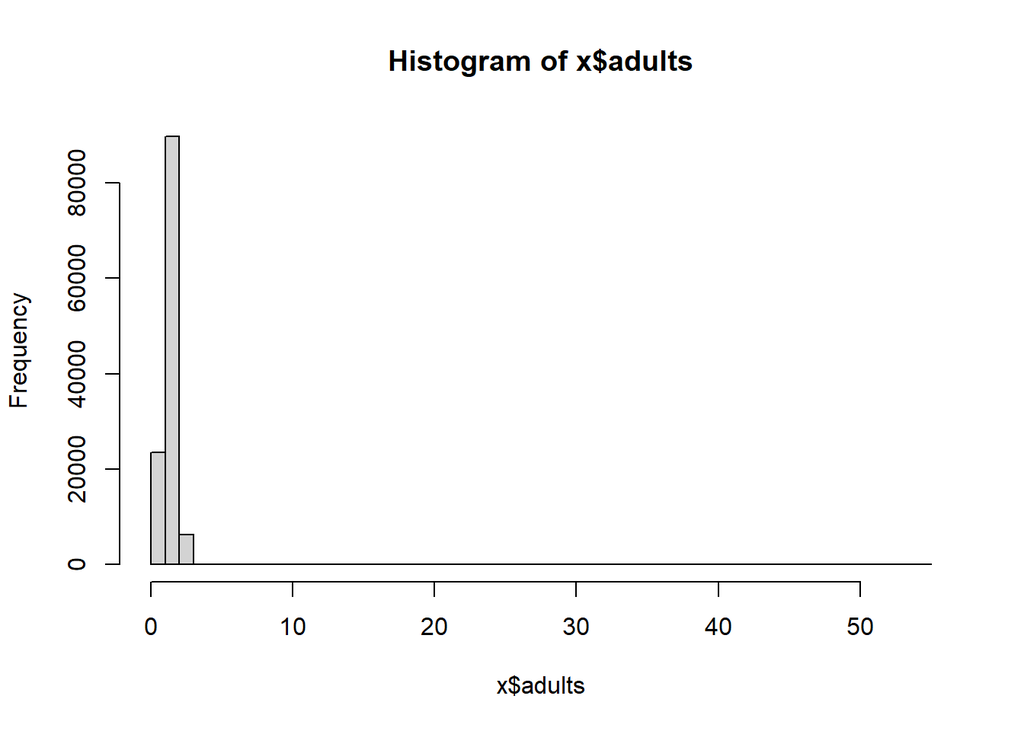

```r
hist(x$adults,breaks=55)
```

```r
sum(is.na(x$adults)) # check if there are NA values
```

```
## [1] 0
```

It can be observed that the histogram shows no bars around the value 55, given that this is a very large set and probably it’s only one or a few cases. In these cases, to analyze the extreme values of a variable, the values of the variable in question can be represented graphically as follows, ordering and plotting the data (if they are numerical, as in this case):

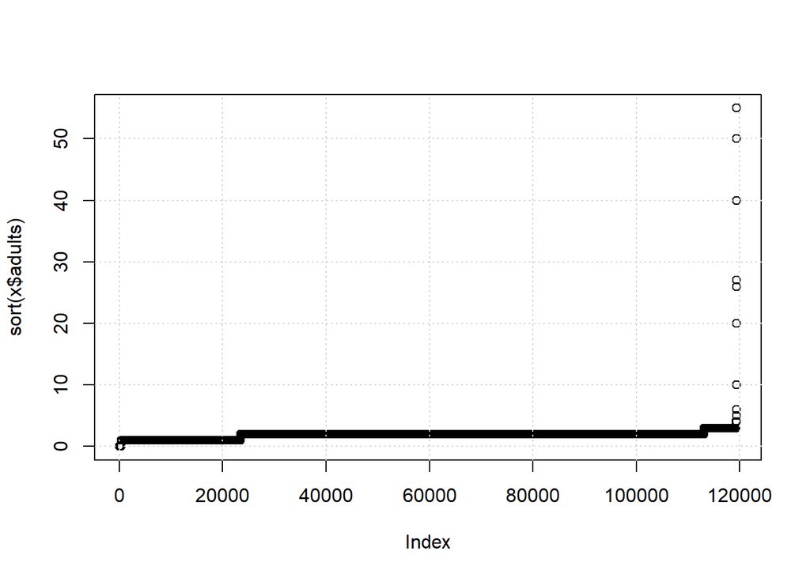

```r
plot(sort(x$adults))
grid()
```

The ‘Index’ represents the position of the element once it’s sorted, but we’re more interested in the Y axis, as we can see that some elements have values of 10 or higher. Since this is an integer variable with a limited set of possible values, we can use table() to visualize them:

```r
table(x$adults)
```

```
##
##     0     1     2     3     4     5     6    10    20    26    27    40    50
##   403 23027 89680  6202    62     2     1     1     2     5     2     1     1
##    55
##     1
```

As you can see, there’s one reservation for 10 adults, two for 20 adults, and so on, up to one for 55 adults! Without going into further detail, we’ll remove all rows with reservations for 10 or more adults:

```r
x=x[x$adults<10,]
```

EXERCISE: Repeat this process with variables ‘children’ and ‘babies’. Try also to change the threshold to less than 5 instead of 10.

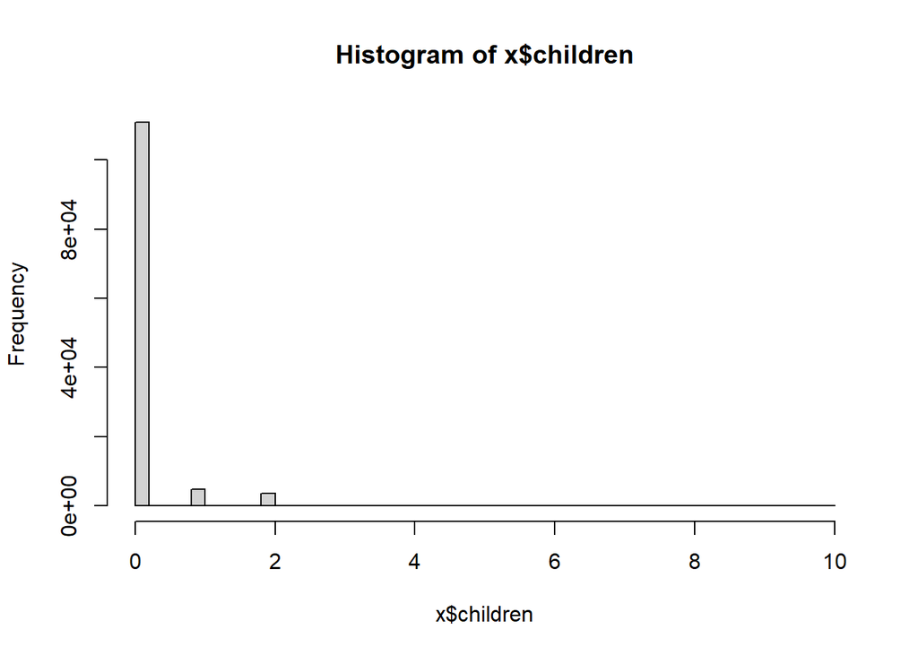

```r
hist(x$children,breaks=55)
```

```r
x[is.na(x$children), ] # check if there are NA values
```

```
##            hotel is_canceled lead_time arrival_date_year arrival_date_month
## 40601 City Hotel           1         2              2015             August
## 40668 City Hotel           1         1              2015             August
## 40680 City Hotel           1         1              2015             August
## 41161 City Hotel           1         8              2015             August
##       arrival_date_week_number arrival_date_day_of_month
## 40601                       32                         3
## 40668                       32                         5
## 40680                       32                         5
## 41161                       33                        13
##       stays_in_weekend_nights stays_in_week_nights adults children babies meal
## 40601                       1                    0      2       NA      0   BB
## 40668                       0                    2      2       NA      0   BB
## 40680                       0                    2      3       NA      0   BB
## 41161                       2                    5      2       NA      0   BB
```

[output cut: 25 more lines]

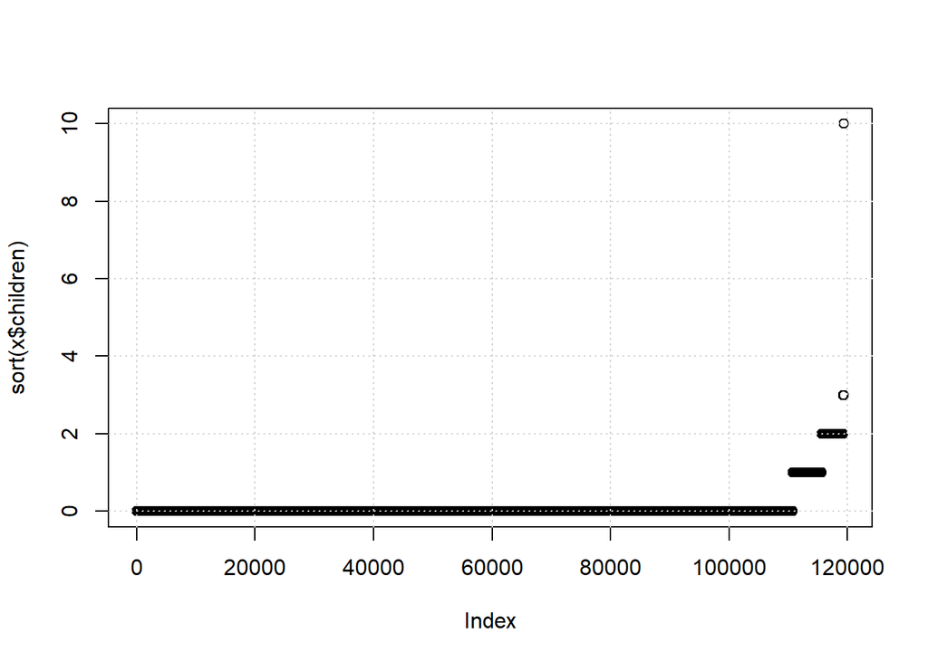

```r
plot(sort(x$children))
grid()
```

```r
table(x$children)
```

```
##
##      0      1      2      3     10
## 110783   4861   3652     76      1
```

As you can see, there’s one reservation for 10 children. I will remove all rows with reservations for 5 or more children:

```r
x = x[!is.na(x$children) & x$children < 5, ]
#x=x[x$children<5,]
```

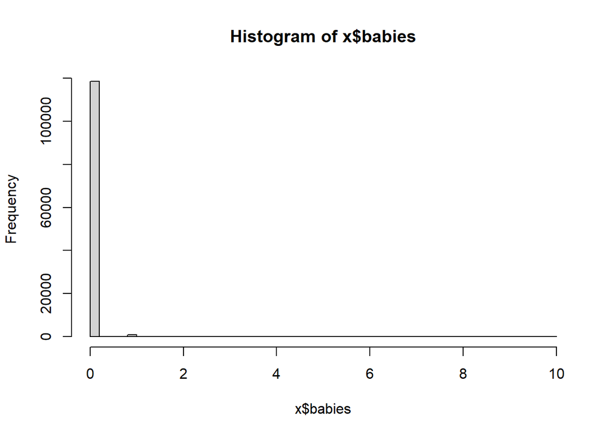

```r
hist(x$babies,breaks=55)
```

```r
x[is.na(x$babies), ] # check if there are NA values
```

```
##  [1] hotel                          is_canceled
##  [3] lead_time                      arrival_date_year
##  [5] arrival_date_month             arrival_date_week_number
##  [7] arrival_date_day_of_month      stays_in_weekend_nights
##  [9] stays_in_week_nights           adults
## [11] children                       babies
## [13] meal                           country
## [15] market_segment                 distribution_channel
## [17] is_repeated_guest              previous_cancellations
## [19] previous_bookings_not_canceled reserved_room_type
## [21] assigned_room_type             booking_changes
## [23] deposit_type                   agent
## [25] company                        days_in_waiting_list
## [27] customer_type                  adr
## [29] required_car_parking_spaces    total_of_special_requests
## [31] reservation_status             reservation_status_date
## <0 rows> (o 0- extensión row.names)
```

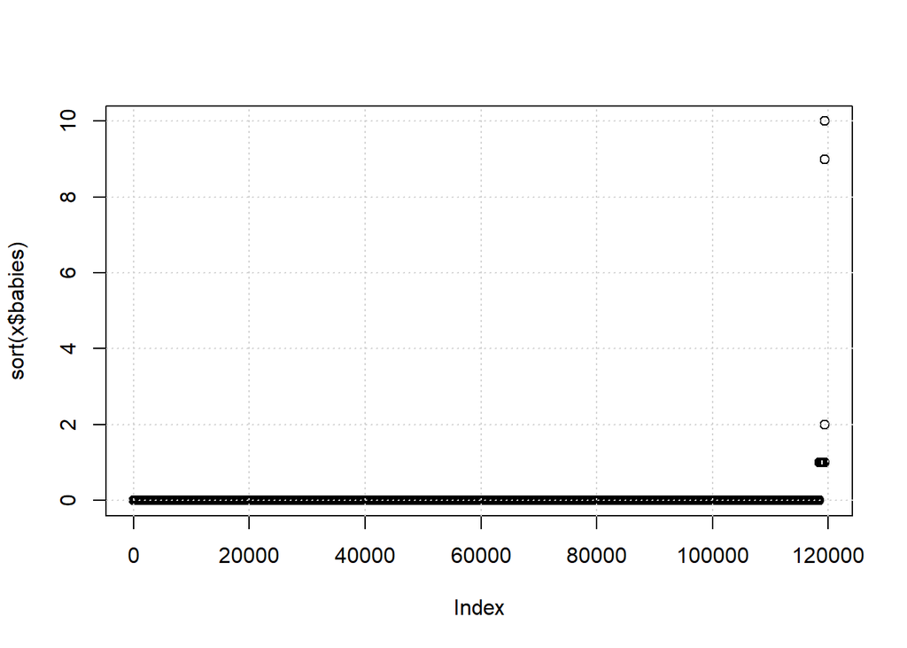

```r
plot(sort(x$babies))
grid()
```

```r
table(x$babies)
```

```
##
##      0      1      2      9     10
## 118455    900     15      1      1
```

As you can see, there’s one reservation for 10 babies and another reservation for 9 babies. I will remove all rows with reservations for 5 or more babies:

```r
x = x[x$babies < 5,]
```

The histogram of the ‘adr’ variable (average daily rate) presents the same problem as the ‘adults’ variable, so we will simply create a graph with the ordered values again:

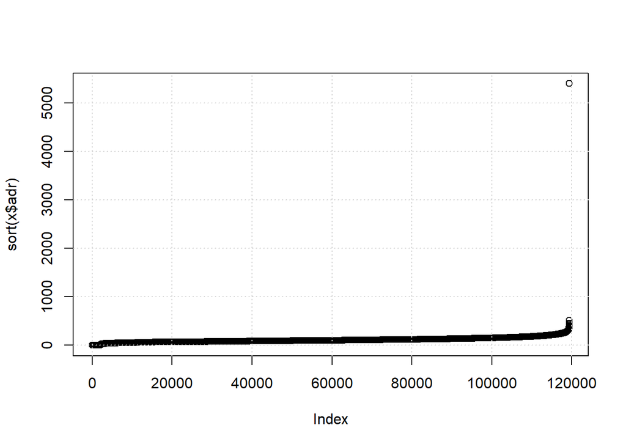

```r
plot(sort(x$adr))
grid()
```

In this case, we observe that only one value is significantly higher than the rest. We consider it an outlier and eliminate it, as well as the negative values which have no a clear explanation, although we keep the 0 values:

```r
x=x[x$adr>=0 & x$adr<1000,]
```

The histogram now provides us with some relevant information. We draw it using the ggplot2 package, which offers many more options than hist():

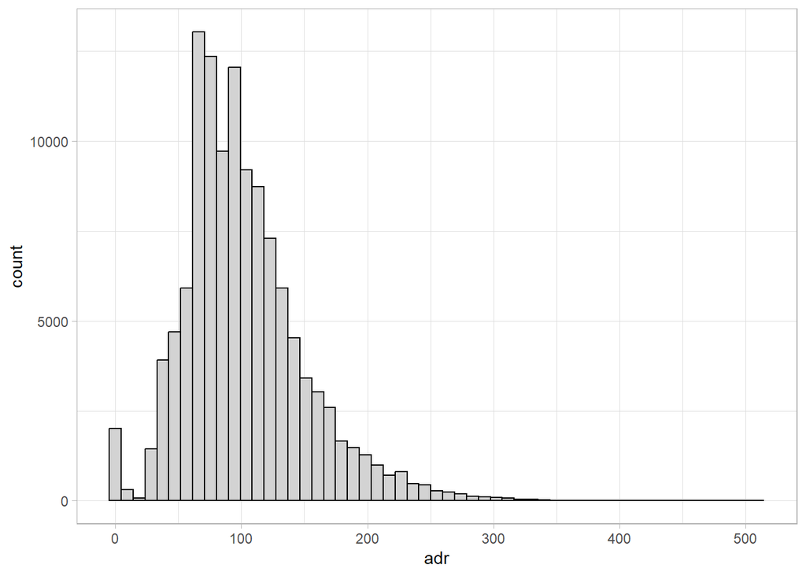

```r
ggplot(data=x, aes(x=adr)) +
  geom_histogram(bins=55, colour="black", fill = "lightgray") +
  theme_light()
```

EXERCISE: improve the graph to make axis, title, etc. more adequate.

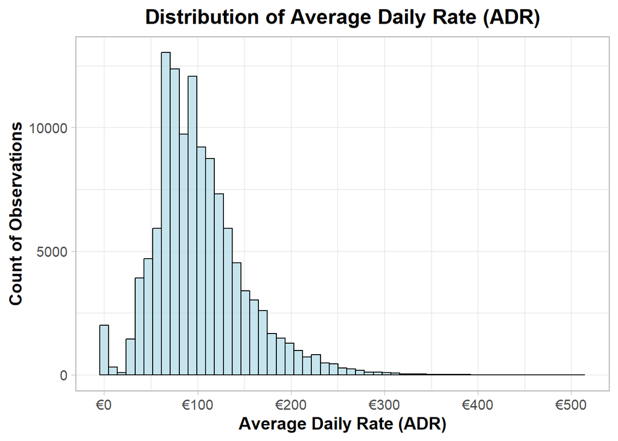

```r
ggplot(data = x, aes(x = adr)) +
  geom_histogram(bins = 55, color = "black", fill = "lightblue", alpha = 0.7) +
  labs(
    title = "Distribution of Average Daily Rate (ADR)",
    x = "Average Daily Rate (ADR)",
    y = "Count of Observations"
  ) +
  theme_light(base_size = 14) +
  theme(
    plot.title = element_text(hjust = 0.5, face = "bold"),
    axis.title.x = element_text(face = "bold"),
    axis.title.y = element_text(face = "bold")
  ) +
  scale_x_continuous(labels = scales::dollar_format(prefix = "€"))
```

We can see that there is a set of approximately 2,000 zero values, which could be analyzed separately, for example. There are R packages that help us estimate this distribution and the parameters that determine it visually, such as the fitdistrplus package, which provides the descdist() function (caution, slow!):

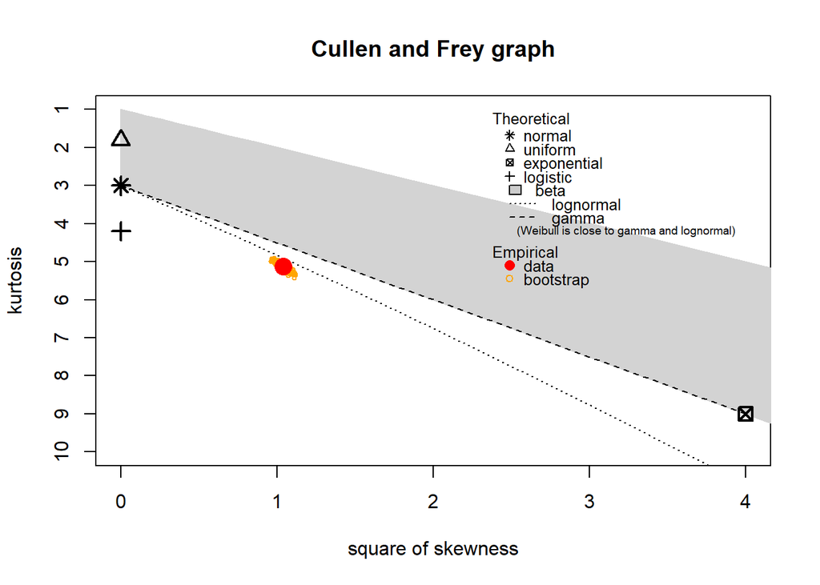

```
## summary statistics
## ------
## min:  0   max:  510
## median:  94.62
## mean:  101.8011
## estimated sd:  48.14287
## estimated skewness:  1.018971
## estimated kurtosis:  5.13332
```

```r
require(fitdistrplus)
descdist(x$adr,boot=1000)
```

As you can see, the real data (observations, a colored dot) and the simulated data (in other color) approximate what a lognormal distribution might look like. However, to experiment with the cleanest possible data set, we will:

1. remove 0-day stays
2. remove 0-cost stays
3. remove stays with no guests
4. replace the NAs in the children variable with 0

```r
x[is.na(x$children),'children']=0
x=x[x$adr>0 &
    (x$stays_in_week_nights+x$stays_in_weekend_nights)>0 &
    (x$adults+x$children+x$babies)>0 &
    !is.na(x$children),]

x[is.na(x$children), ]
```

```
##  [1] hotel                          is_canceled
##  [3] lead_time                      arrival_date_year
##  [5] arrival_date_month             arrival_date_week_number
##  [7] arrival_date_day_of_month      stays_in_weekend_nights
##  [9] stays_in_week_nights           adults
## [11] children                       babies
## [13] meal                           country
## [15] market_segment                 distribution_channel
## [17] is_repeated_guest              previous_cancellations
## [19] previous_bookings_not_canceled reserved_room_type
## [21] assigned_room_type             booking_changes
## [23] deposit_type                   agent
## [25] company                        days_in_waiting_list
## [27] customer_type                  adr
## [29] required_car_parking_spaces    total_of_special_requests
## [31] reservation_status             reservation_status_date
## <0 rows> (o 0- extensión row.names)
```

## Categorical variables

For categorical variables, the summary() function gives us a first idea of the possible values each can take. For example, in the original set (before removing outliers), there are 79,330 reservations at a city hotel (Lisbon) and 40,060 at a resort (Algarve). We can ask ourselves whether the cost distribution is the same for both groups, either by using the appropriate statistical test or simply by comparing histograms, in this case using the ggplot2 package, which is much more powerful for creating all kinds of graphs:

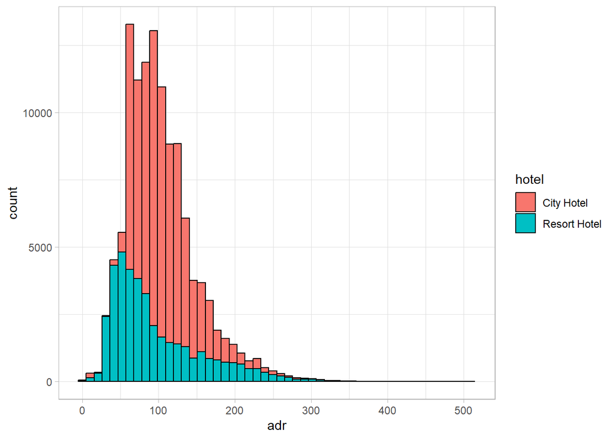

```r
# require(ggplot2)
ggplot(data=x, aes(x=adr, fill=hotel)) +
  geom_histogram(bins=50, colour="black") +
  theme_light()
```

It can be seen that the most common prices in Lisbon (city hotels) are slightly to the right of the most common prices in the Algarve (resort hotels), although the highest prices in Lisbon decrease more rapidly than in the Algarve. By using a violin plot, we can see more detail, especially if we also show the typical quartiles of a box plot:

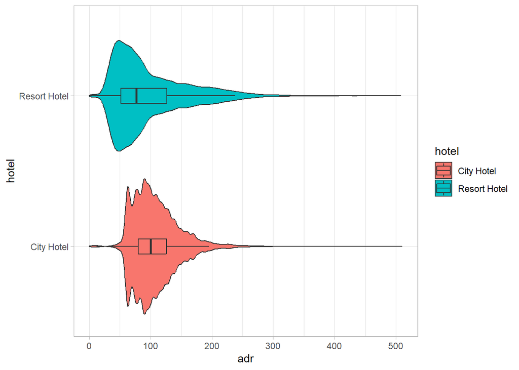

```r
ggplot(data=x, aes(x=hotel, y=adr, fill=hotel)) +
  geom_violin() + geom_boxplot(width=.1, outliers = F) +
  coord_flip() +
  theme_light()
```

There is an R package called ggstatsplot that has specific functions for each type of graph, including appropriate statistical tests to determine if there are differences between groups:

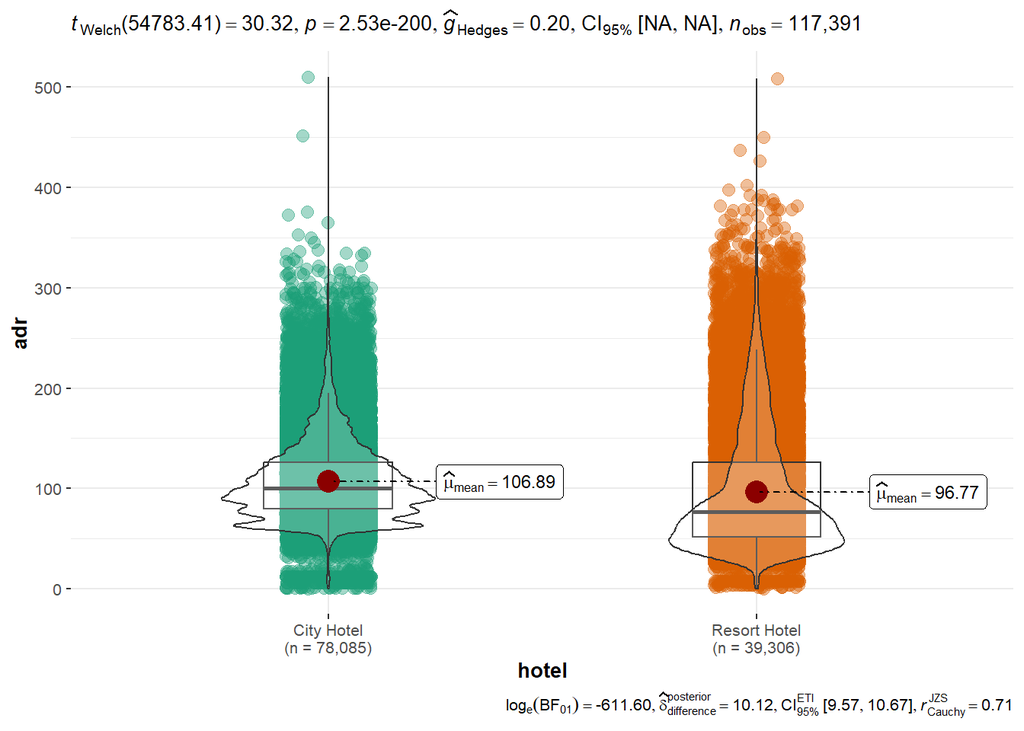

```r
# require(ggstatsplot)
ggbetweenstats(data=x, x=hotel, y=adr)
```

Another interesting variable is the hotel guests’ origin (‘country’). The problem is that this variable has many different values (178), so we should focus on the countries with the most tourists, also showing whether they choose a city hotel or a resort:

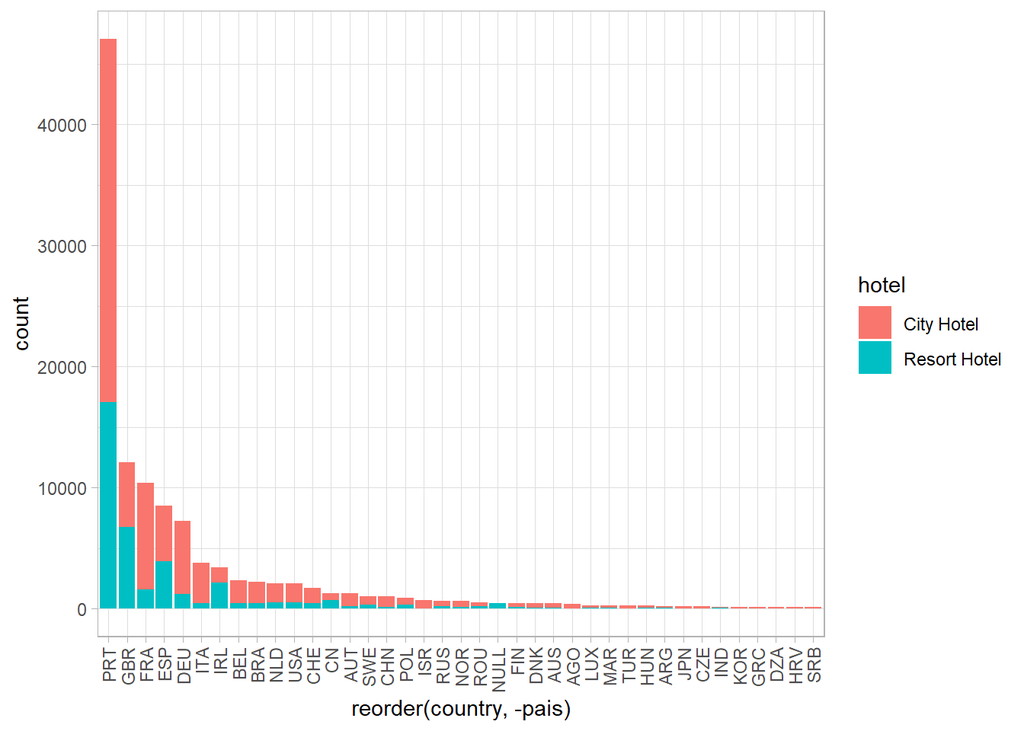

```r
# require(tidyverse)
# countries with at least 100 bookings
xx = x %>% group_by(country) %>% mutate(pais=n()) %>% filter(pais>=100)
xx$country=factor(xx$country)
ggplot(data=xx, aes(x=reorder(country, -pais))) +
  geom_bar(stat="count", aes(fill=hotel)) +
  theme_light() +
  theme(axis.text.x = element_text(angle = 90, vjust = 0.5, hjust=1))
```

Obviously, Portugal (PRT) ranks first, followed by neighboring countries such as Great Britain, France, and Spain. Visitors from Great Britain and Ireland are most likely to choose a resort, while those from France, Germany, and Italy primarily visit Lisbon.

EXERCISE: Are there differences between residents of Portugal and the rest? Yes, the number of people that go to both city and resort are much higher than the rest, obviusly beacause they are local residents.

Another interesting variable is ‘is_canceled’, which indicates whether a reservation was canceled or not (37.0% of the time). We can observe the relationship between two categorical variables using a mosaic chart:

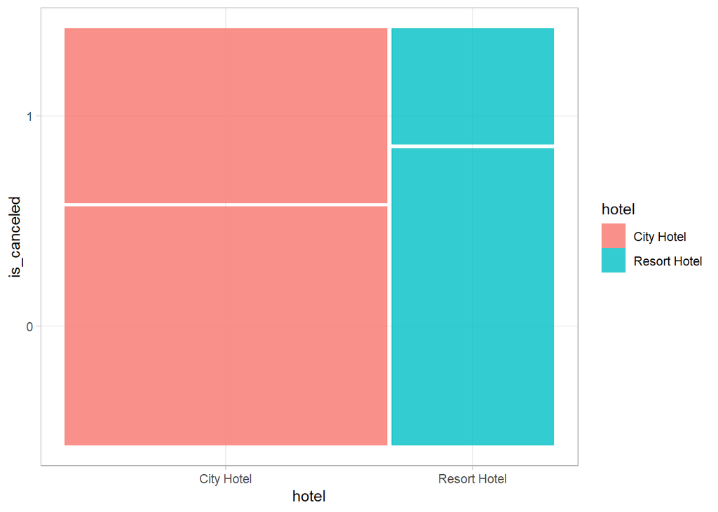

```r
# require(ggmosaic)
x$is_canceled=as.factor(x$is_canceled)
ggplot(data=x) +
  geom_mosaic(aes(x=product(is_canceled, hotel), fill=hotel)) +
  theme_light()
```

It can be seen that the cancellation rate (denoted by 1 on the Y-axis) at a resort is lower than that of a hotel in Lisbon. On the X-axis, the relative size of each column also corresponds to the proportion of each hotel type. It is important not to consider the Y-axis labels (0/1) as the actual numerical cancellation rate, as this can be misleading.

EXERCISE: which other type of graph could be used to represent this data?

[figure not shown]

```r
# Copia del dataset original
dfx1 <- x

# Asegurar factores legibles
dfx1$is_canceled <- factor(dfx1$is_canceled, levels = c(0, 1), labels = c("No Cancelado", "Cancelado"))

# Calcular proporciones y etiquetas
dfx1_pie <- dfx1 %>%
  count(hotel, is_canceled) %>%
  group_by(hotel) %>%
  mutate(
    prop = n / sum(n),
    pct_label = paste0(round(prop * 100, 1), "%"),
    ypos = cumsum(prop) - prop / 2  # posición vertical dentro del segmento
  )

# Gráfico tipo pie con etiquetas
ggplot(dfx1_pie, aes(x = "", y = prop, fill = is_canceled)) +
  geom_col(width = 1, color = "white") +
  coord_polar("y") +
  facet_wrap(~ hotel) +
  geom_text(aes(y = ypos, label = pct_label), color = "white", size = 4, fontface = "bold") +
  labs(
    title = "Proporción de cancelaciones por tipo de hotel",
    fill = "Estado de reserva"
  ) +
  theme_void() +
  theme(
    plot.title = element_text(hjust = 0.5, face = "bold"),
    strip.text = element_text(face = "bold")
  )
```

In the case of cancellation by country for the countries with more tourists:

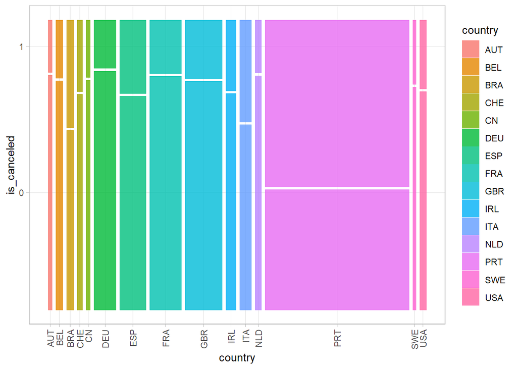

```r
# at least 1000 bookings
xx = x %>% group_by(country) %>% mutate(pais=n()) %>% filter(pais>=1000)
xx$country=factor(xx$country)
ggplot(data=xx) +
  geom_mosaic(aes(x=product(is_canceled, country), fill=country)) +
  theme_light() +
  theme(axis.text.x = element_text(angle = 90, vjust = 0.5, hjust=1))
```

It can be seen that the cancellation rate is much higher for local tourists (from Portugal, PRT), while it is much lower for the rest of the countries. However, this graph is not easy to read; in this case, there is no order of either the countries or the percentage of cancellations.

EXERCISE: Improve the previous graph to make it more understandable and consider whether it is possible to visualize the relationships between three or more categorical variables.

**1. Use readable labels for is_canceled** Convert it to a labeled factor: “Canceled” vs “Not Canceled”.

**2. Control the number of countries shown** Even with ≥1000 bookings, many countries can still overwhelm the plot. Consider showing only the top 10–15 by count.

**3. Enhance color palette** Using a perceptually uniform or qualitative palette helps distinguish countries better.

```r
# Copy and prep
dfx2 <- x %>%
  mutate(is_canceled = factor(is_canceled, levels = c(0,1), labels = c("Not Canceled", "Canceled"))) %>%
  group_by(country) %>%
  mutate(pais = n()) %>%
  filter(pais >= 1000) %>%
  ungroup()

# Keep only top 10 countries
top_countries <- dfx2 %>%
  count(country, sort = TRUE) %>%
  top_n(10) %>%
  pull(country)
```

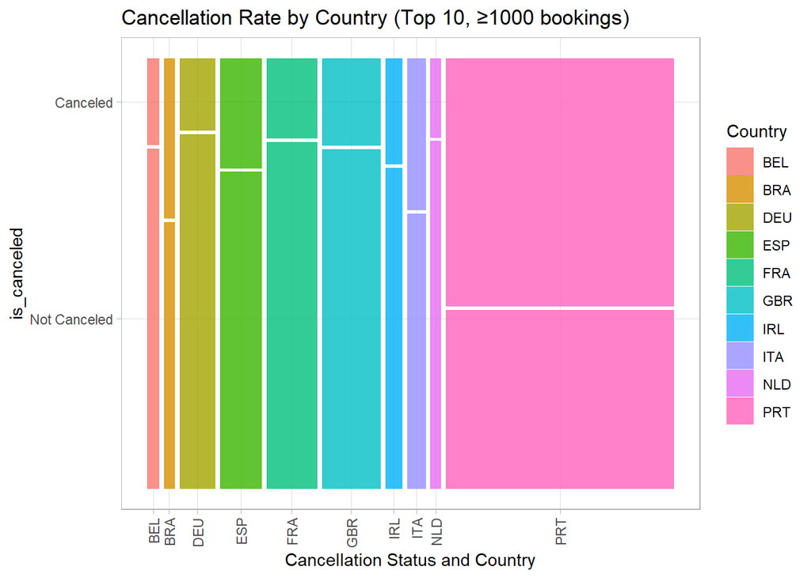

```r
dfx2 <- dfx2 %>% filter(country %in% top_countries)

# Transforms Country to factor
dfx2$country=factor(dfx2$country)

# Plot
ggplot(data = dfx2) +
  geom_mosaic(aes(x = product(is_canceled, country), fill = country)) +
  theme_light() +
  theme(
    axis.text.x = element_text(angle = 90, vjust = 0.5, hjust = 1),
    legend.position = "right"
  ) +
  labs(
    title = "Cancellation Rate by Country (Top 10, ≥1000 bookings)",
    x = "Cancellation Status and Country",
    fill = "Country"
  )
```

```r
  theme(axis.text.x = element_text(angle = 90, vjust = 0.5, hjust=1))
```

[output not shown]

**4. Alternative: Grouped Bar Plot (simpler & cleaner)** Mosaic plots are useful but get messy with more categories. Bar plots are often easier to interpret.

```r
# Copy and prep
dfx2 <- x %>%
  mutate(is_canceled = factor(is_canceled, levels = c(0,1), labels = c("Not Canceled", "Canceled"))) %>%
  group_by(country) %>%
  mutate(pais = n()) %>%
  filter(pais >= 1000) %>%
  ungroup()

# Keep only top 10 countries
top_countries <- dfx2 %>%
  count(country, sort = TRUE) %>%
  top_n(10) %>%
  pull(country)
```

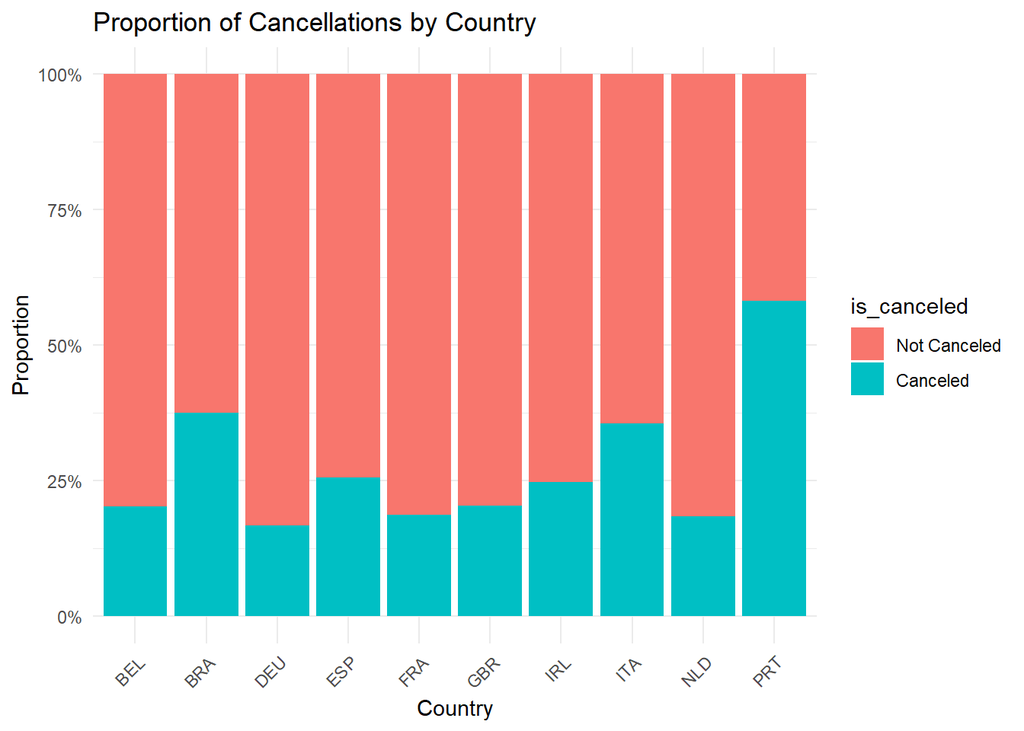

```r
dfx2 <- dfx2 %>% filter(country %in% top_countries)

df_summary <- dfx2 %>%
  count(country, is_canceled) %>%
  group_by(country) %>%
  mutate(prop = n / sum(n))

ggplot(df_summary, aes(x = reorder(country, -prop), y = prop, fill = is_canceled)) +
  geom_bar(stat = "identity", position = "fill") +
  labs(title = "Proportion of Cancellations by Country", y = "Proportion", x = "Country") +
  scale_y_continuous(labels = scales::percent) +
  theme_minimal() +
  theme(axis.text.x = element_text(angle = 45, hjust = 1))
```

[figure not shown]

```r
ggplot(dfx2, aes(x = is_canceled, fill = is_canceled)) +
  geom_bar() +
  facet_wrap(~ country, scales = "free_y") +
  labs(
    title = "Cantidad de cancelaciones por país (Top 15)",
    x = "Estado de cancelación",
    y = "Número de reservas"
  ) +
  theme_minimal() +
  theme(strip.text = element_text(face = "bold"))
```

Finally, let’s analyze the behavior of reservations relative to the arrival date. First, using the R lubridate package (a marvel for manipulating date and time data), we’ll create a ‘day’ variable to determine the day of the week the hotel was checked in and analyze how many reservations there were each day:

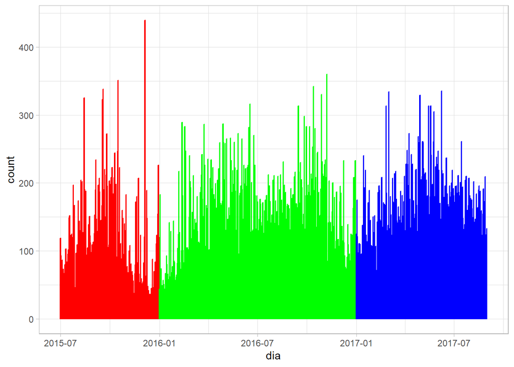

```r
# require(lubridate)
x$dia=as_date(paste0(x$arrival_date_year,'-',x$arrival_date_month,'-',x$arrival_date_day_of_month))
ggplot(data=x,aes(x=dia,group=arrival_date_year,color=as.factor(arrival_date_year))) +
  geom_bar() + scale_color_manual(values=c("2015"="red","2016"="green","2017"="blue")) +
  theme_light() +
  theme(legend.position='none')
```

EXERCISE: Improve and split the above graph by hotel type or country of origin.

**1. By hotel**

We’ll also use a line plot (geom_line(stat=“count”)) instead of bars for smoother time series visualization and include a legend.

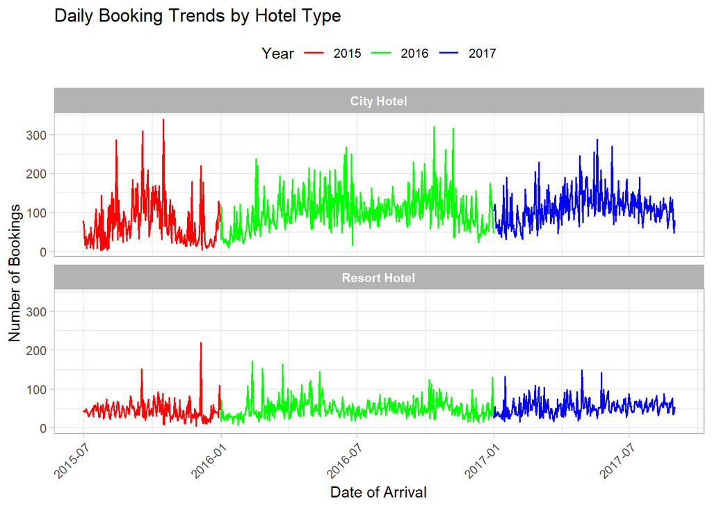

```r
# Copia del dataset
dfx3 <- x

# Crear columna de fecha
dfx3$dia <- as_date(paste0(x$arrival_date_year,'-',x$arrival_date_month,'-',x$arrival_date_day_of_month))

# Agregar número de reservas por día y año
dfx3_plot <- dfx3 %>%
  group_by(hotel, dia, arrival_date_year) %>%
  summarise(n = n(), .groups = "drop") %>%
  mutate(year = as.factor(arrival_date_year))


# Graficar con líneas
ggplot(dfx3_plot, aes(x = dia, y = n, color = year)) +
  geom_line(linewidth = 0.7) +
  facet_wrap(~ hotel, ncol = 1) +
  scale_color_manual(values = c("2015" = "red", "2016" = "green", "2017" = "blue")) +
  labs(
    title = "Daily Booking Trends by Hotel Type",
    x = "Date of Arrival",
    y = "Number of Bookings",
    color = "Year"
  ) +
  theme_light() +
  theme(
    legend.position = "top",
    strip.text = element_text(face = "bold"),
    axis.text.x = element_text(angle = 45, hjust = 1)
  )
```

**2. By country**

```r
# Filter top 5 countries
top_countries <- dfx3 %>%
  count(country, sort = TRUE) %>%
  top_n(5) %>%
  pull(country)
```

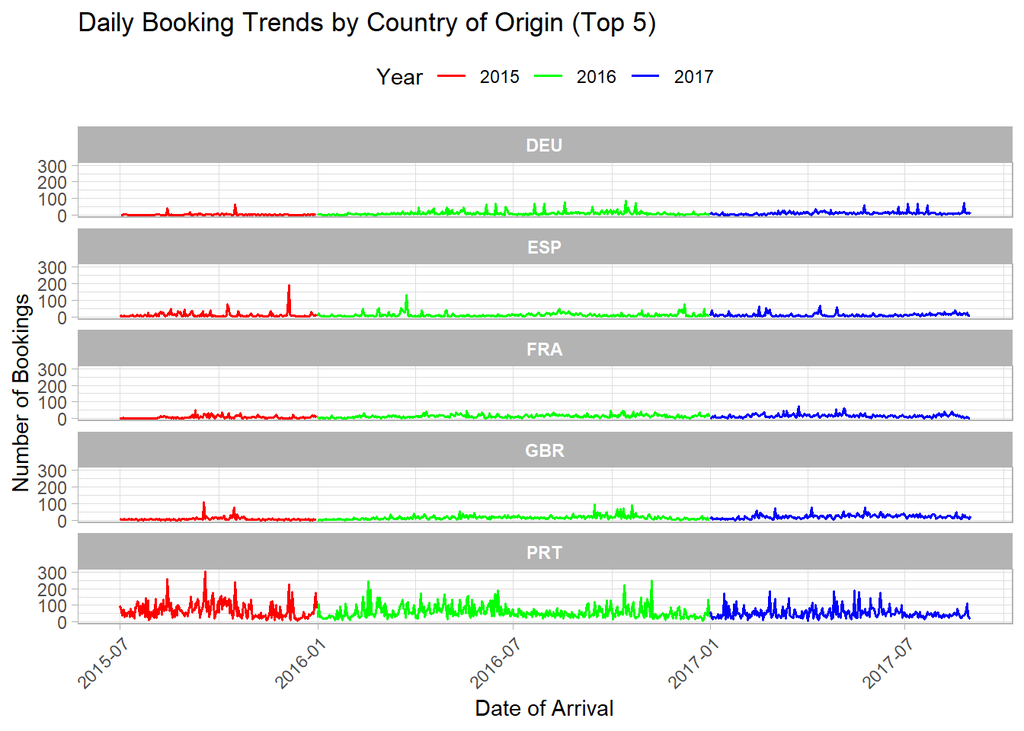

```r
dfx3 <- dfx3 %>% filter(country %in% top_countries)

# Transforms Country to factor
dfx3$country=factor(dfx3$country)

# Plot
ggplot(data = dfx3, aes(x = dia, group = arrival_date_year, color = as.factor(arrival_date_year))) +
  geom_line(stat = "count", size = 0.7) +
  scale_color_manual(values = c("2015" = "red", "2016" = "green", "2017" = "blue")) +
  facet_wrap(~ country, ncol = 1) +
  labs(
    title = "Daily Booking Trends by Country of Origin (Top 5)",
    x = "Date of Arrival",
    y = "Number of Bookings",
    color = "Year"
  ) +
  theme_light() +
  theme(
    legend.position = "top",
    strip.text = element_text(face = "bold"),
    axis.text.x = element_text(angle = 45, hjust = 1)
  )
```

As described in the article, the data covers the period from July 1, 2015, to August 31, 2017. Some peaks can be observed that might be interesting to explain (what happened those days, i.e. 2015-12-05?). You can check Google Trends to get some insights:

https://trends.google.es/trends/explore?date=2015-01-01%202017-12-31&q=lisboa,algarve&hl=es

```r
max(table(x$dia))
```

```
## [1] 439
```

```r
which.max(table(x$dia))
```

```
## 2015-12-05
##        158
```

With the computed day ‘dia’, along with the variables ‘stays_in_week’ and ‘weekend_nights’, we can try to manually categorize the trip type according to the following criteria (this is arbitrary, clearly improvable):

1. if ‘stays_in_weekend_nights’ is zero => work trip
2. if ‘stays_in_week_nights’ is zero or one and in this case the entry is on Friday => weekend
3. if ‘stays_in_week_nights’ is five and ‘stays_in_weekend_nights’ is three (that is, from Saturday or Sunday to Saturday or Sunday) => week holiday package
4. if ‘stays_in_weekend_nights’ is one or two and ‘stays_in_week_days’ is five or less => work + rest
5. the rest of combinations => holidays

```r
# require(lubridate)
x$tipo=ifelse(x$stays_in_weekend_nights==0, "work",
       ifelse(x$stays_in_week_nights==0, "weekend",
       ifelse(x$stays_in_week_nights==1 & wday(x$dia)==6, "weekend",
       ifelse(x$stays_in_week_nights==5 &
              (x$stays_in_weekend_nights==3 |
               x$stays_in_weekend_nights==4), "package",
       ifelse(x$stays_in_week_nights<=5 &
              x$stays_in_weekend_nights<3, "work+rest",
       "rest")))))
```

One way to refine this classification would be to look at the number of adults, children, and infants to decide whether it is a business traveler or a family. The possibilities are endless: you can enrich the dataset with geographic data (distance between countries), demographic data, economic data (per capita income), weather data (in both Portugal and the country of origin), etc.

EXERCISE: You must explore such enriched dataset and, in this process of exploration, decide what story you want to tell about it. Some ideas:

**1)** do tourists from different countries travel in different dates?

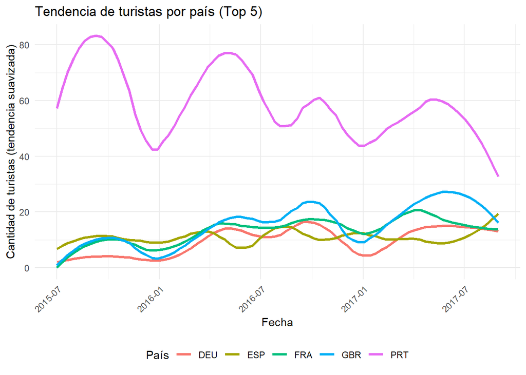

```r
# Asegurar que 'dia' es tipo fecha
x$dia <- as.Date(x$dia)

# Obtener los 10 países con más turistas
top_5_countries <- x %>%
  count(country, name = "total") %>%
  arrange(desc(total)) %>%
  slice_head(n = 5) %>%
  pull(country)

# Filtrar dataset
x_top <- x %>%
  filter(country %in% top_5_countries)

# Agrupar por día y país
grouped_top <- x_top %>%
  group_by(dia, country) %>%
  summarise(count = n(), .groups = "drop")

# Graficar líneas suavizadas
ggplot(grouped_top, aes(x = dia, y = count, color = country)) +
  geom_smooth(se = FALSE, method = "loess", span = 0.3, linewidth = 1.2) +
  labs(
    title = "Tendencia de turistas por país (Top 5)",
    x = "Fecha",
    y = "Cantidad de turistas (tendencia suavizada)",
    color = "País"
  ) +
  theme_minimal() +
  theme(
    legend.position = "bottom",
    axis.text.x = element_text(angle = 45, hjust = 1)
  )
```

**2)** differences in cancellations among groups (countries, type of stay, …)

% of cancellations per country

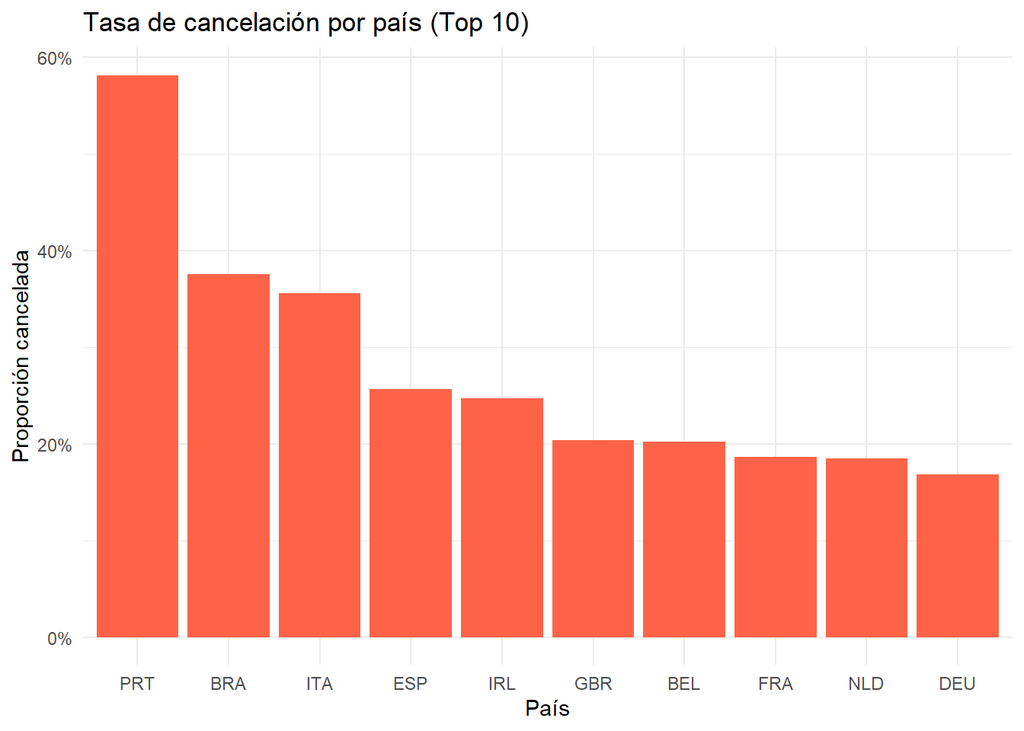

```r
# Top 10 países con más reservas
top_countries <- x %>%
  count(country, sort = TRUE) %>%
  slice_head(n = 10) %>%
  pull(country)

# Filtrar
x_top <- x %>%
  filter(country %in% top_countries)

x_top <- x_top %>%
  mutate(is_canceled = as.numeric(as.character(is_canceled)))

# Calcular proporción de cancelaciones
cancel_by_country <- x_top %>%
  group_by(country) %>%
  summarise(
    cancel_rate = mean(is_canceled),
    total = n()
  )

# Graficar
ggplot(cancel_by_country, aes(x = reorder(country, -cancel_rate), y = cancel_rate)) +
  geom_col(fill = "tomato") +
  labs(
    title = "Tasa de cancelación por país (Top 10)",
    x = "País",
    y = "Proporción cancelada"
  ) +
  scale_y_continuous(labels = scales::percent) +
  theme_minimal()
```

Cancellation per type (tipo) of trip

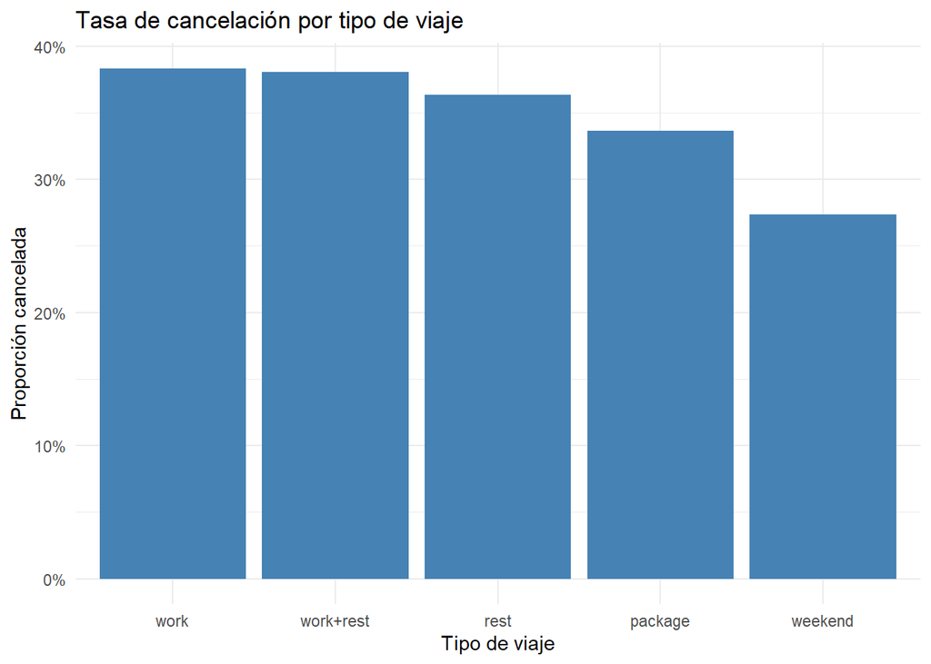

```r
xx <- x %>%
  mutate(is_canceled = as.numeric(as.character(is_canceled)))

cancel_by_tipo <- xx %>%
  group_by(tipo) %>%
  summarise(
    cancel_rate = mean(is_canceled),
    total = n()
  )

ggplot(cancel_by_tipo, aes(x = reorder(tipo, -cancel_rate), y = cancel_rate)) +
  geom_col(fill = "steelblue") +
  labs(
    title = "Tasa de cancelación por tipo de viaje",
    x = "Tipo de viaje",
    y = "Proporción cancelada"
  ) +
  scale_y_continuous(labels = scales::percent) +
  theme_minimal()
```

Country and trip type – Combined cancellation rate

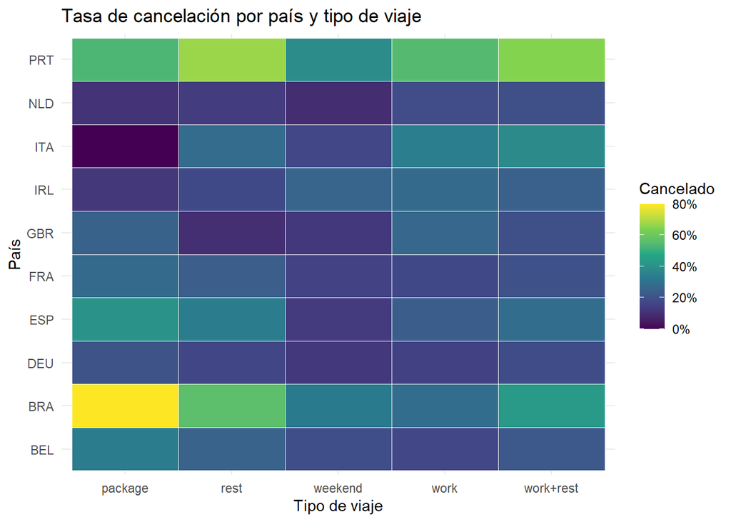

```r
xx <- x %>%
  mutate(is_canceled = as.numeric(as.character(is_canceled)))

cancel_heatmap <- xx %>%
  filter(country %in% top_countries) %>%
  group_by(country, tipo) %>%
  summarise(cancel_rate = mean(is_canceled), .groups = "drop")

ggplot(cancel_heatmap, aes(x = tipo, y = country, fill = cancel_rate)) +
  geom_tile(color = "white") +
  scale_fill_viridis_c(labels = scales::percent) +
  labs(
    title = "Tasa de cancelación por país y tipo de viaje",
    x = "Tipo de viaje",
    y = "País",
    fill = "Cancelado"
  ) +
  theme_minimal()
```

**3)** relationship between type of stay ‘tipo’ and cost ‘adr’

Boxplot: Compare ‘adr’ distribution by ‘tipo’ Ideal for viewing medians, ranges, and price outliers.

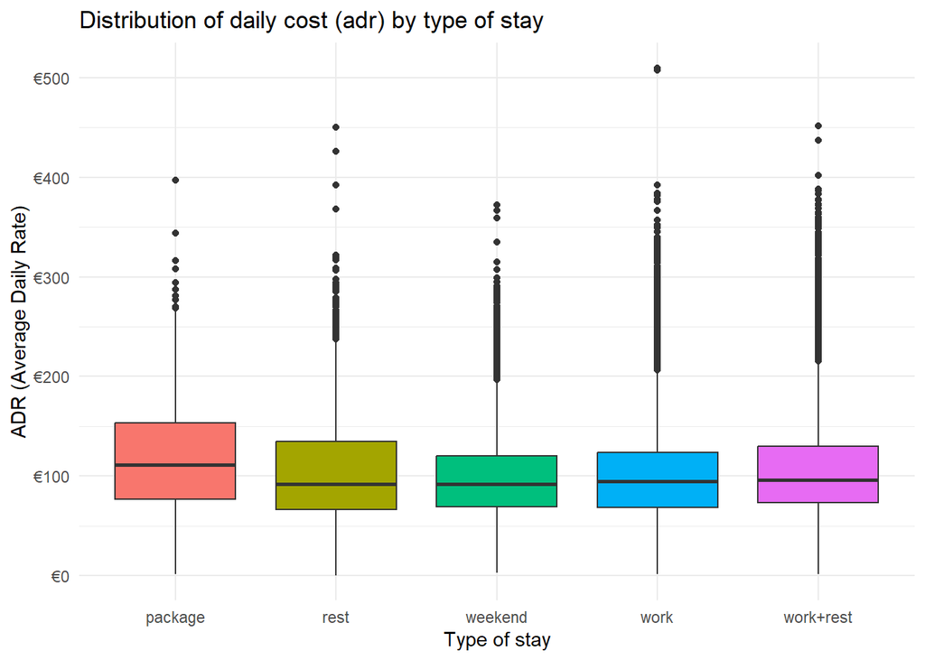

```r
ggplot(x, aes(x = tipo, y = adr, fill = tipo)) +
  geom_boxplot() +
  labs(
    title = "Distribution of daily cost (adr) by type of stay",
    x = "Type of stay",
    y = "ADR (Average Daily Rate)"
  ) +
  theme_minimal() +
  theme(legend.position = "none") +
  scale_y_continuous(labels = scales::dollar_format(prefix = "€"))
```

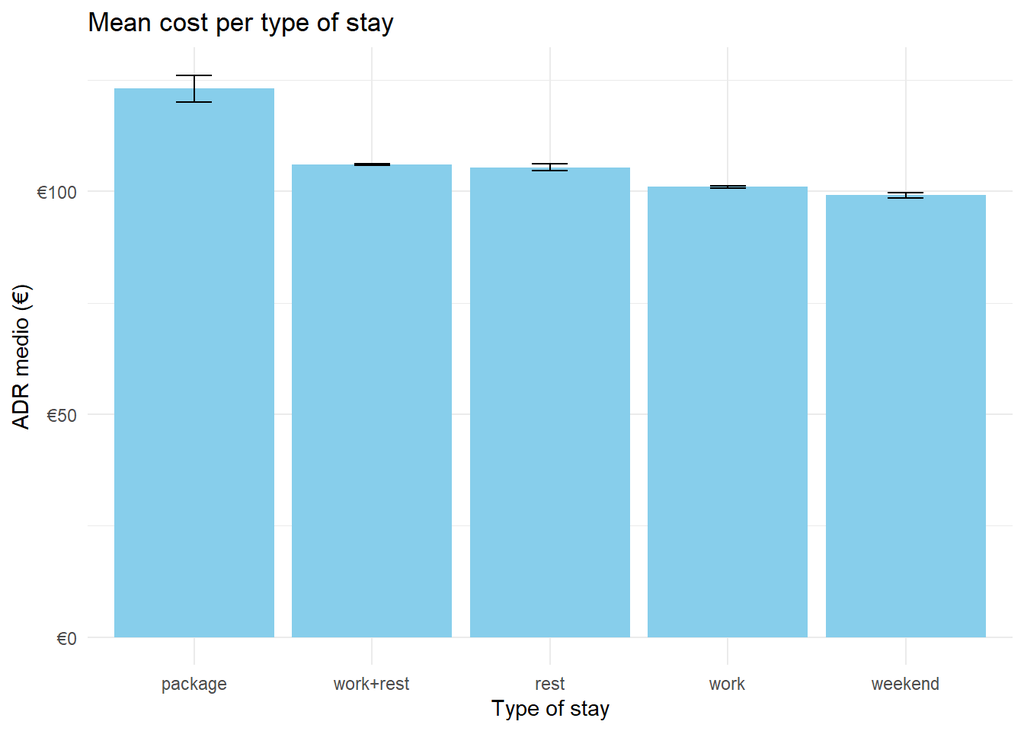

```r
xx %>%
  group_by(tipo) %>%
  summarise(
    mean_adr = mean(adr, na.rm = TRUE),
    se = sd(adr, na.rm = TRUE) / sqrt(n())
  ) %>%
  ggplot(aes(x = reorder(tipo, -mean_adr), y = mean_adr)) +
  geom_col(fill = "skyblue") +
  geom_errorbar(aes(ymin = mean_adr - se, ymax = mean_adr + se), width = 0.2) +
  labs(
    title = "Mean cost per type of stay",
    x = "Type of stay",
    y = "ADR medio (€)"
  ) +
  theme_minimal() +
  scale_y_continuous(labels = scales::dollar_format(prefix = "€"))
```

Violin plot

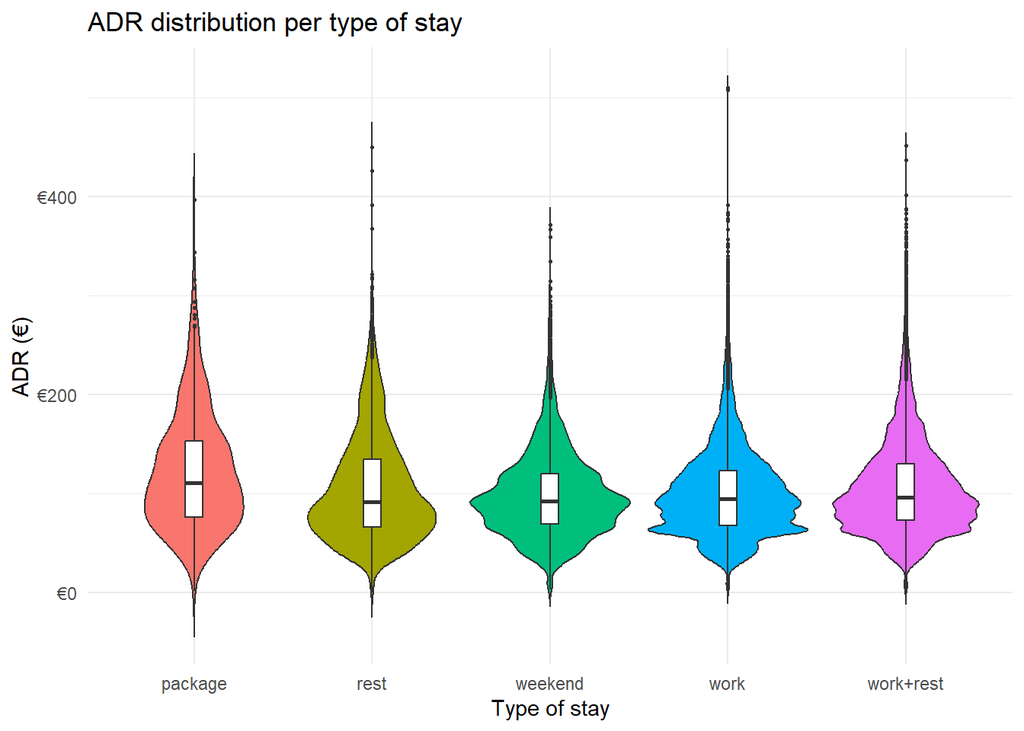

```r
ggplot(x, aes(x = tipo, y = adr, fill = tipo)) +
  geom_violin(trim = FALSE) +
  geom_boxplot(width = 0.1, fill = "white", outlier.size = 0.5) +
  labs(
    title = "ADR distribution per type of stay",
    x = "Type of stay",
    y = "ADR (€)"
  ) +
  theme_minimal() +
  theme(legend.position = "none") +
  scale_y_continuous(labels = scales::dollar_format(prefix = "€"))
```

**4)** differences among groups with respect to hotel type (city / resort)

Stacked Bar Plot: Proportions of Stay Types by Hotel Type This graph shows the distribution of stay types (tipo) within each hotel type, with bars representing the proportion of each stay type.

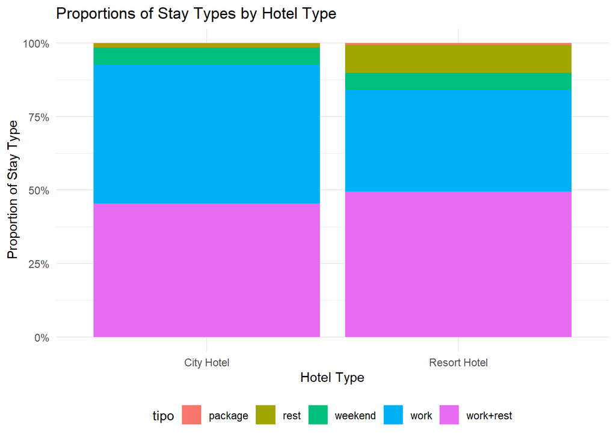

```r
xx %>%
  count(hotel, tipo) %>%
  group_by(hotel) %>%
  mutate(proportion = n / sum(n)) %>%
  ggplot(aes(x = hotel, y = proportion, fill = tipo)) +
  geom_bar(stat = "identity") +
  labs(
    title = "Proportions of Stay Types by Hotel Type",
    x = "Hotel Type",
    y = "Proportion of Stay Type"
  ) +
  theme_minimal() +
  scale_y_continuous(labels = scales::percent) +
  theme(legend.position = "bottom")
```

Boxplot for ADR by Hotel Type and Stay Type This will show how adr varies between the two hotel types (Resort Hotel and City Hotel) for each tipo (stay type).

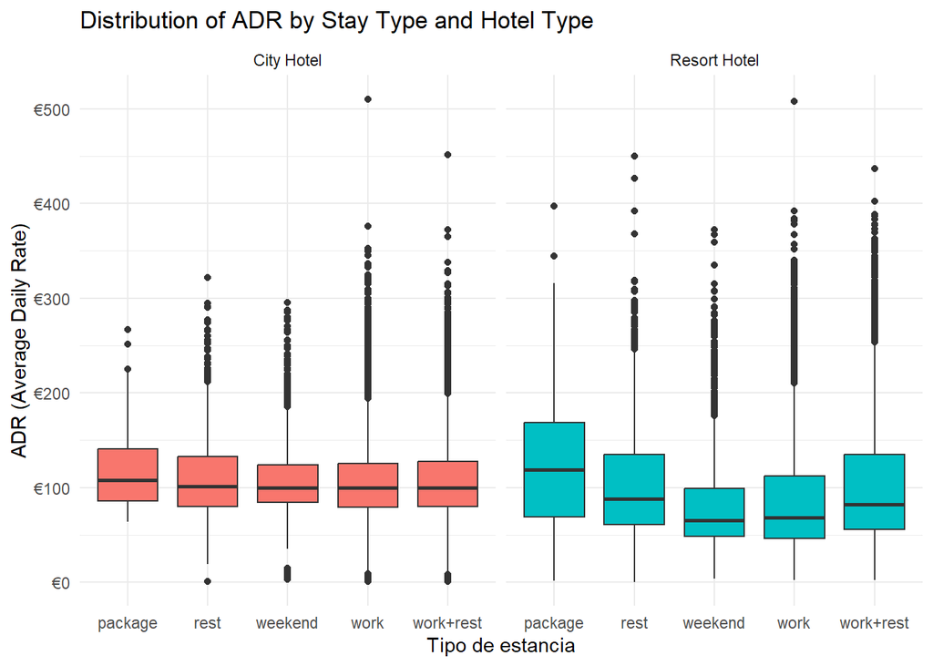

```r
ggplot(x, aes(x = tipo, y = adr, fill = hotel)) +
  geom_boxplot() +
  facet_wrap(~ hotel) +  # Separate boxplots by hotel type
  labs(
    title = "Distribution of ADR by Stay Type and Hotel Type",
    x = "Tipo de estancia",
    y = "ADR (Average Daily Rate)"
  ) +
  theme_minimal() +
  theme(legend.position = "none") +
  scale_y_continuous(labels = scales::dollar_format(prefix = "€"))
```

NOTE: This is a good example of using ChatGPT or other generative AI to ask interesting questions about the proposed dataset. The following paper describes the potential uses of generative AI in the different phases of creating a data visualization for storytelling:

https://ieeexplore.ieee.org/stamp/stamp.jsp?arnumber=10891192